# Trabajo Final Módulo Ciencia de Datos

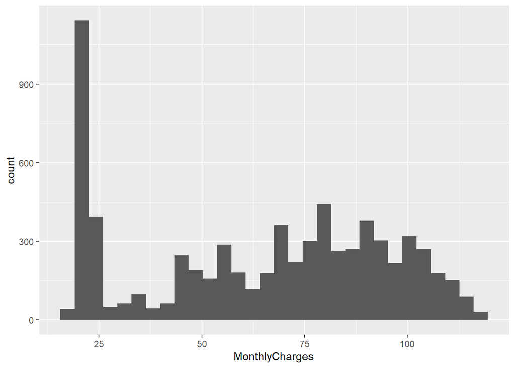

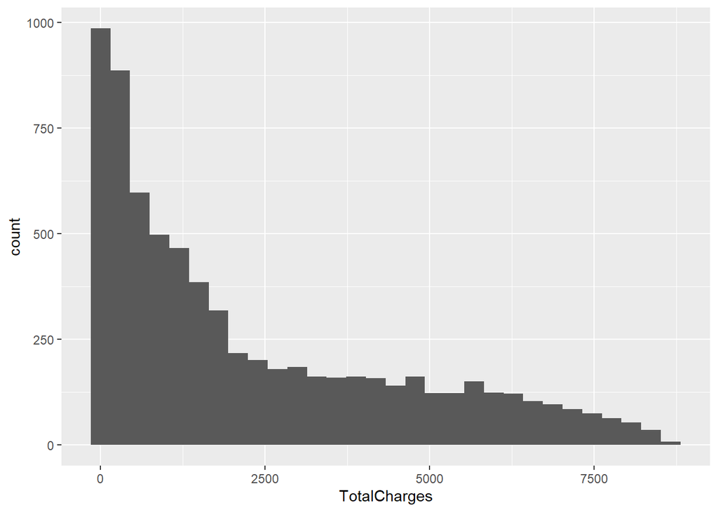

o Muestra los gráficos anteriores coloreados según la variable Churn para poder ver la proporción de “churners” en función del valor de las distintas variables. Se muestran dos ejemplos a continuación

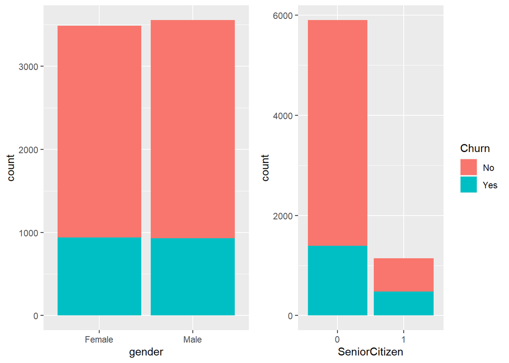

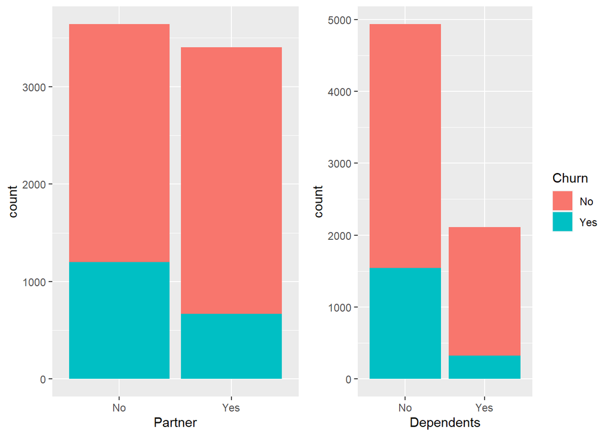

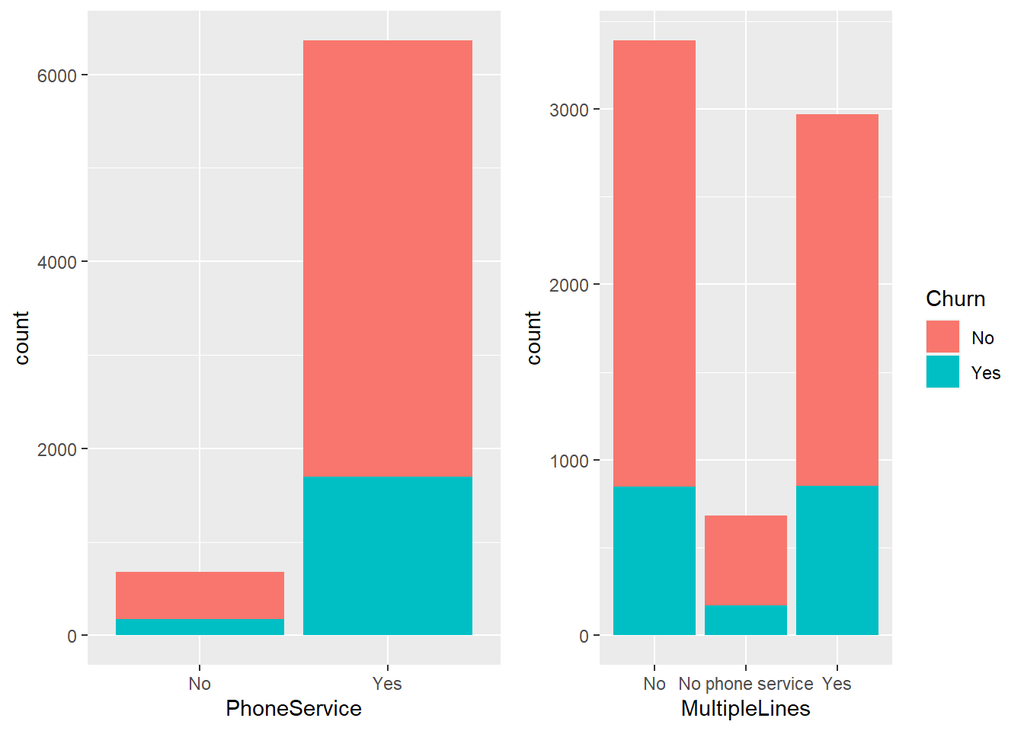

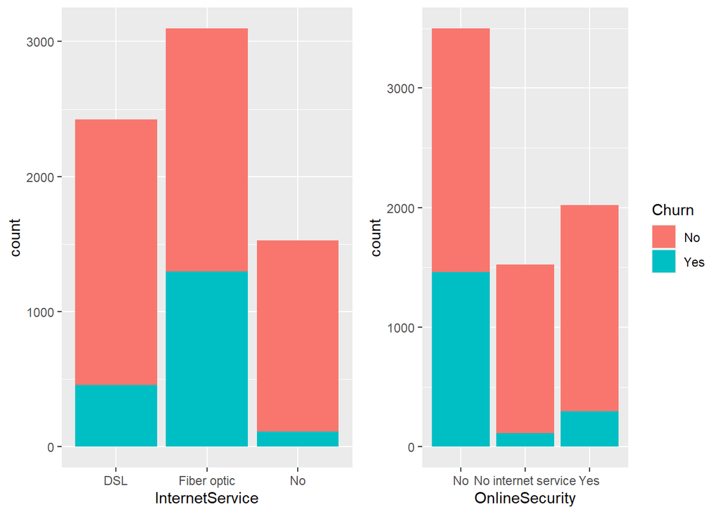

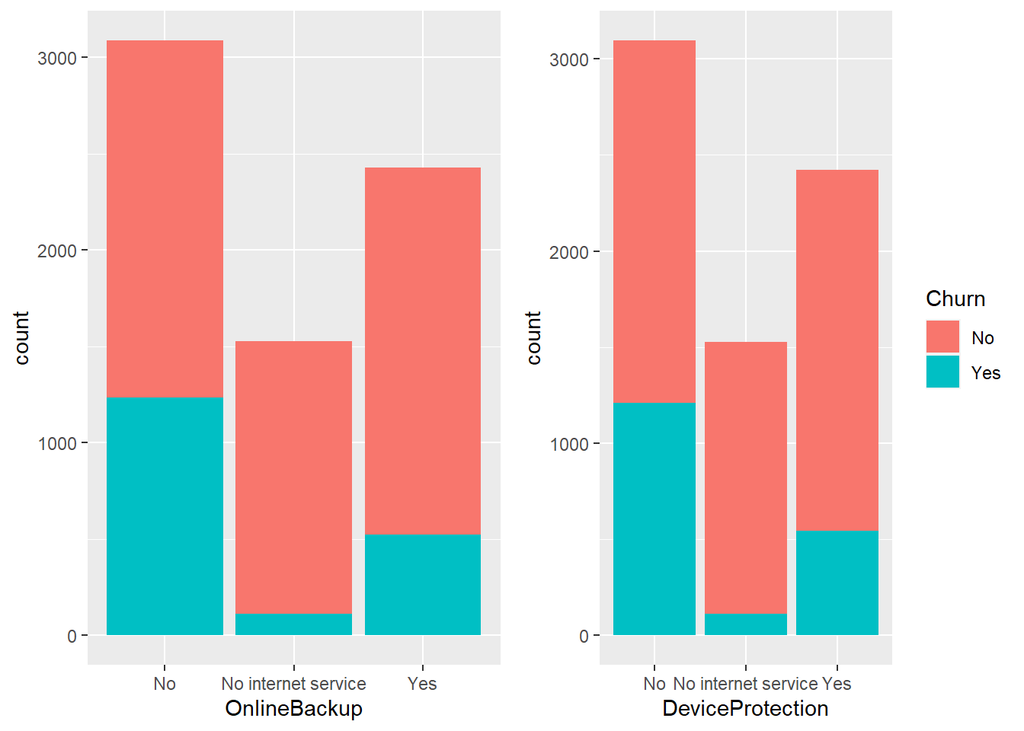

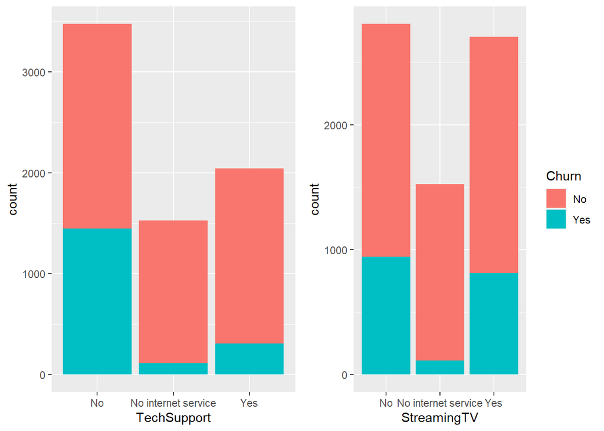

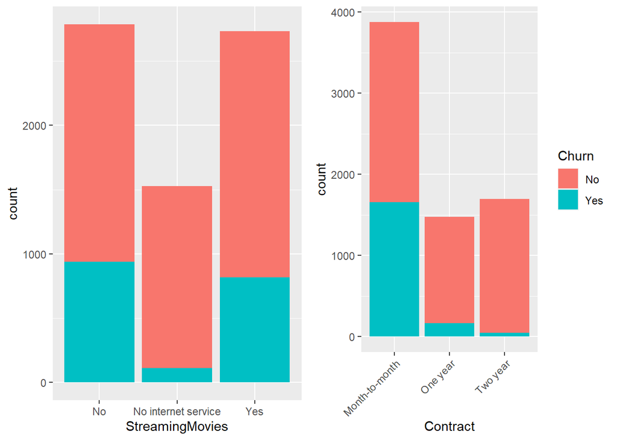

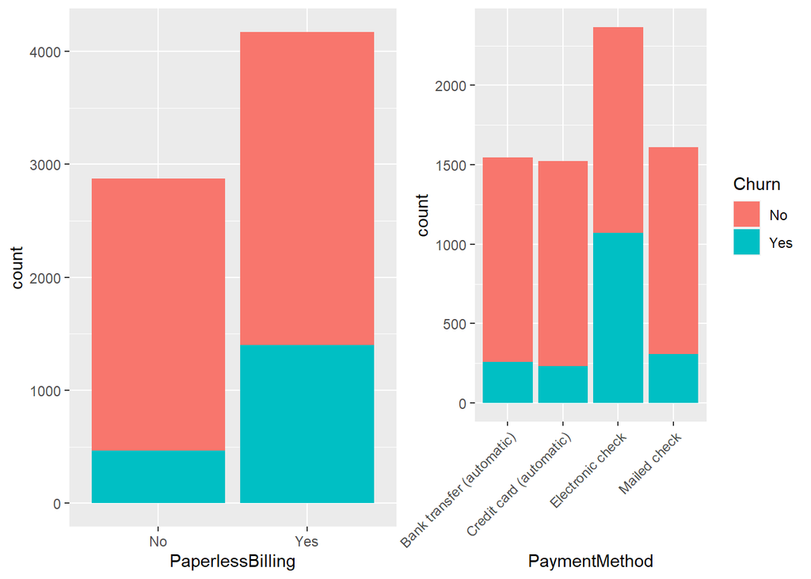

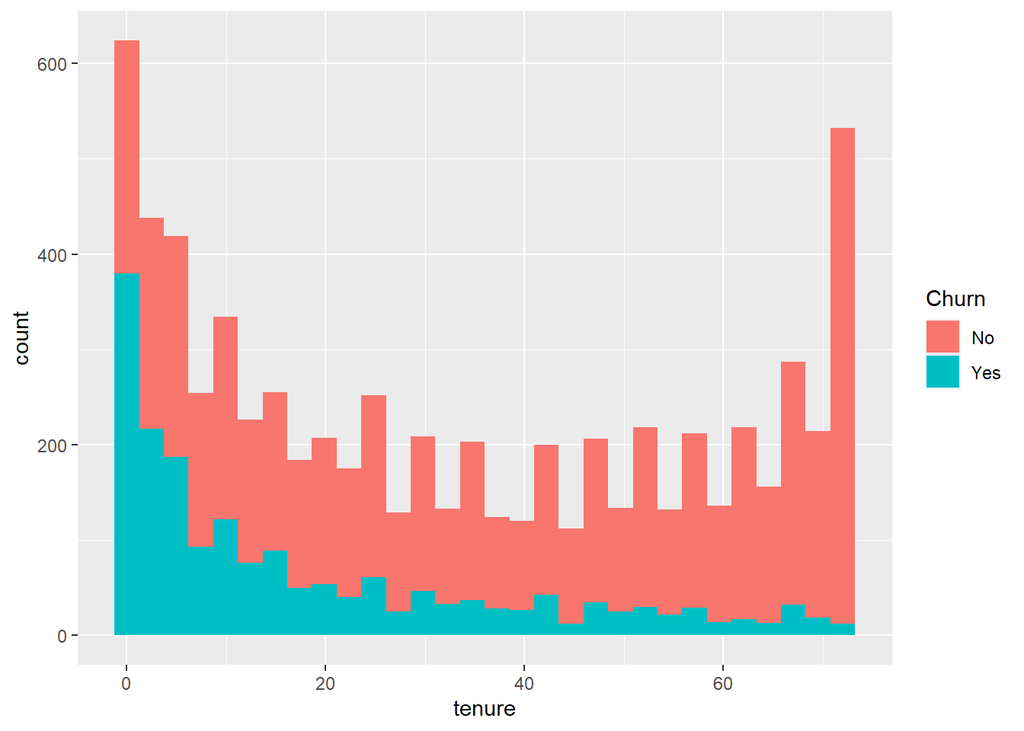

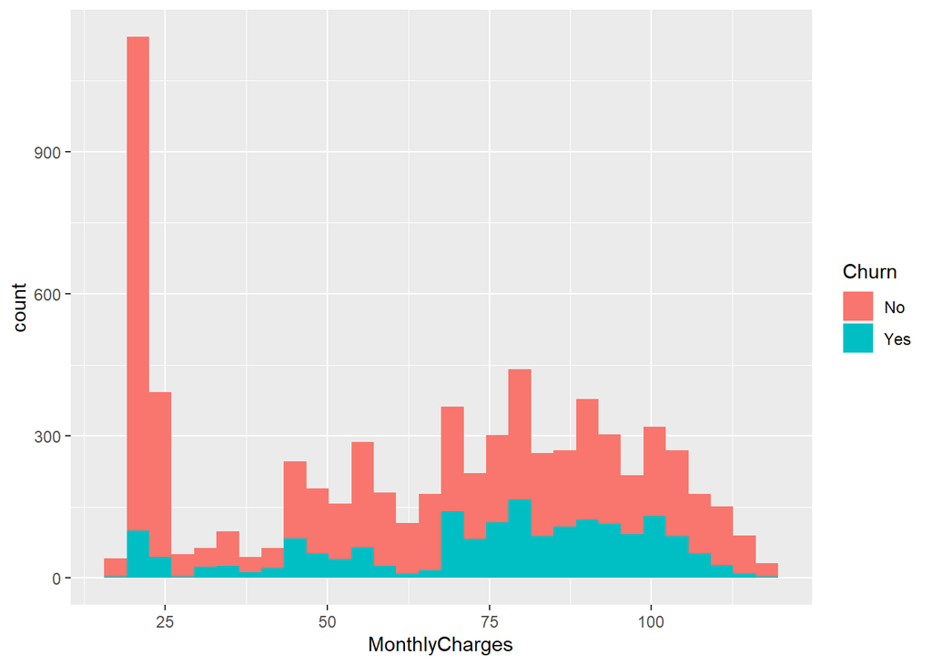

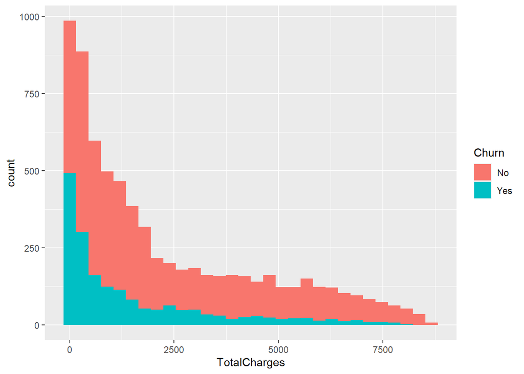

- De cara a la predicción del gasto mensual:
  - Para las variables categóricas realiza un boxplot que muestre la distribución del gasto mensual (MonthlyCharges) para cada valor de las variables.

  -Para las variables numéricas realiza un gráfico de dispersión que muestre la correlación entre variables. Puedes hacerlo uno a uno o usar un gráfico de correlación conjunto.

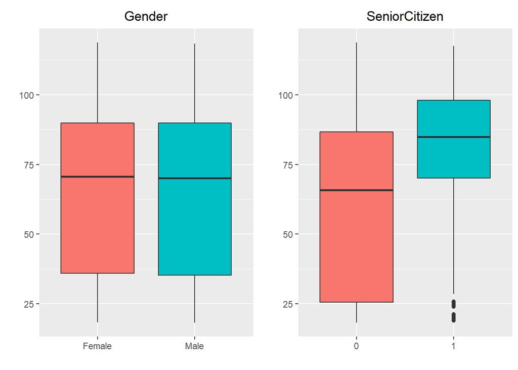

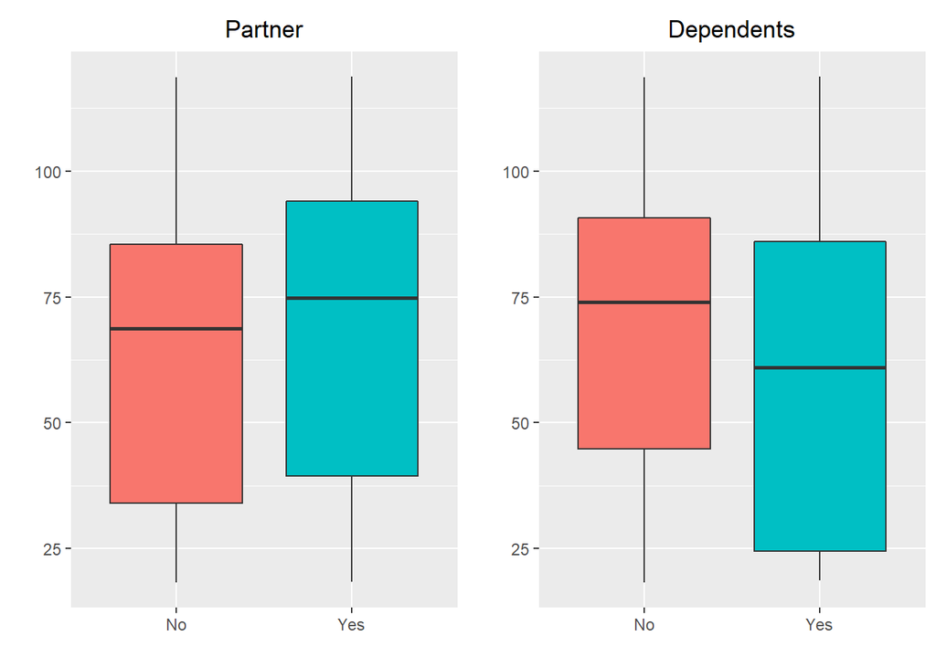

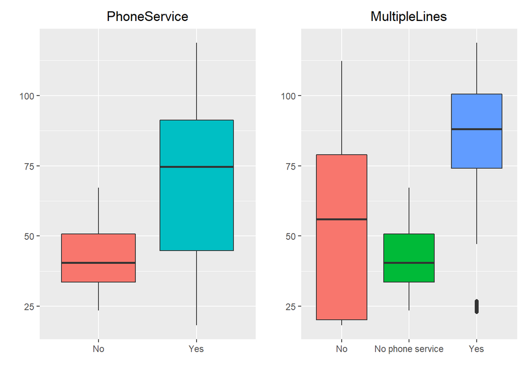

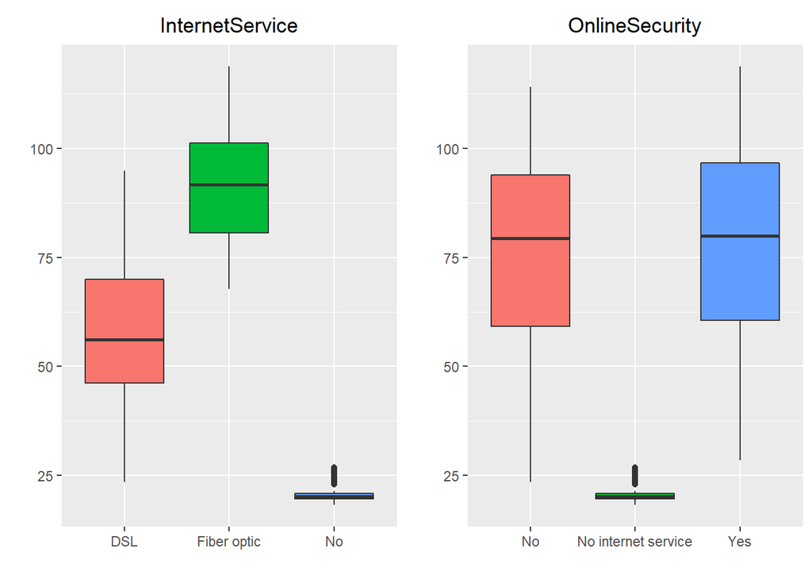

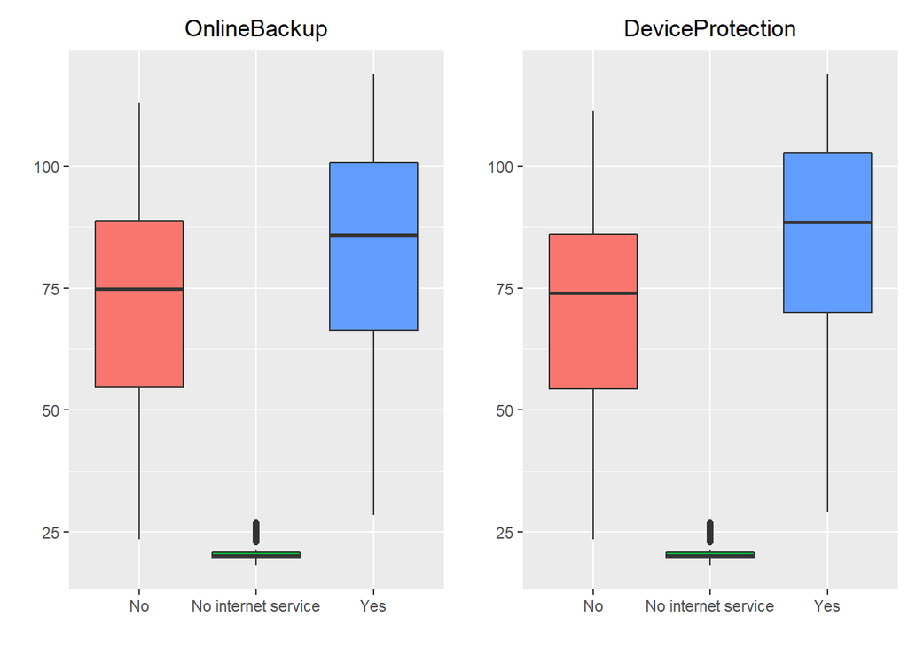

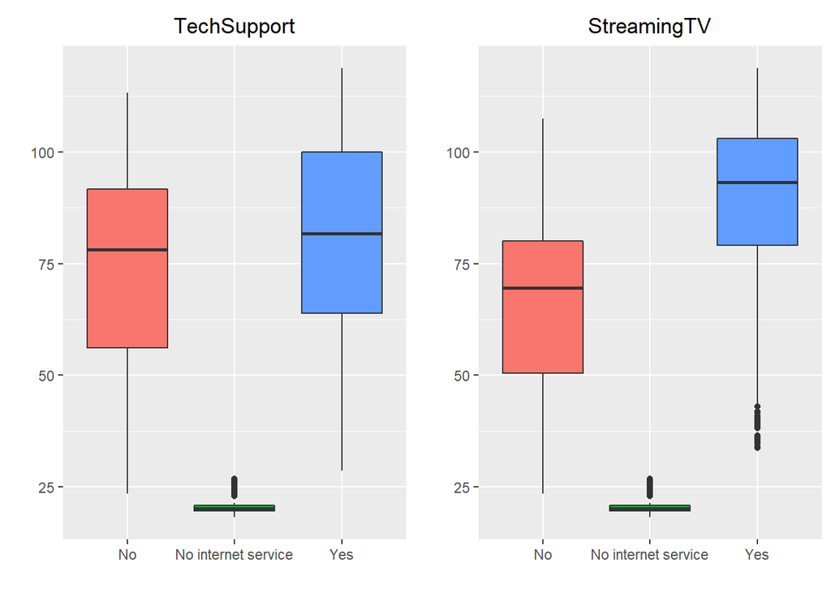

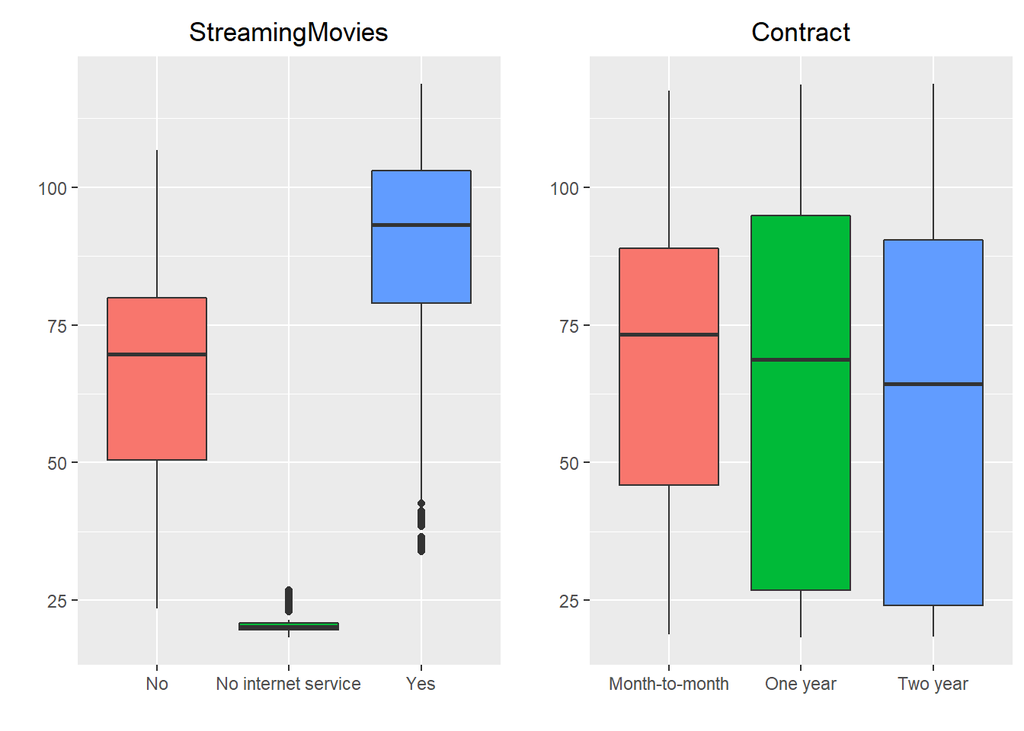

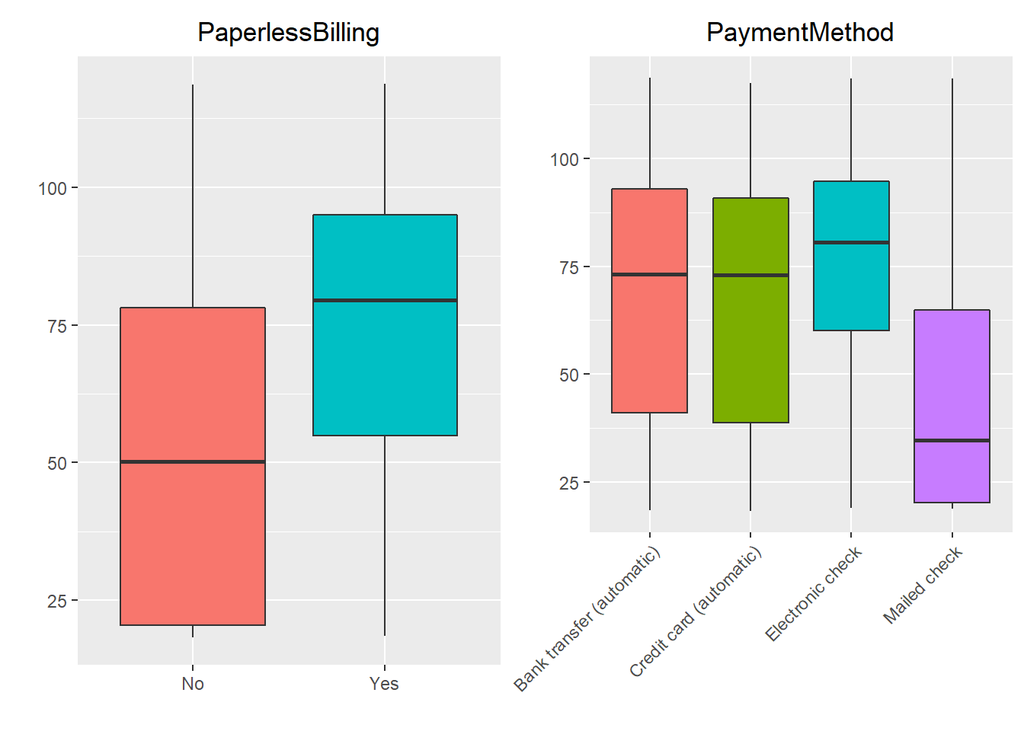

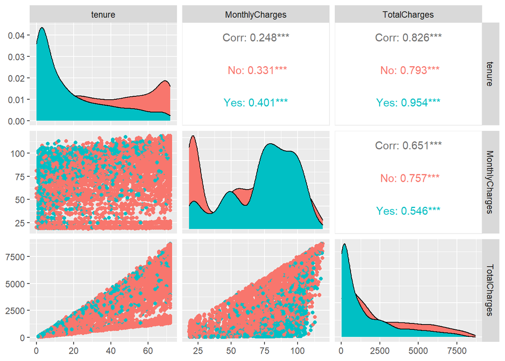

- Cualquier otra cosa que se te ocurra y creas que da información sobre los problemas que queremos resolver en el proyecto.

Si hay alguna variable que deba ser considerada como categórica en lugar de como numérica transfórmala. Es necesario para que los modelos de regresión o clasificación funcionen correctamente.

Antes de seguir adelante, vamos a dividir el conjunto de datos en dos subconjuntos de entrenamiento y test:

- churn_train: Contendrá las 5000 primeras de churn_data
- churn_test: Contendrá las filas de la 5001 al final de churn_data

## Modelos de Regresión

Vamos a diseñar y ajustar un modelo de regresión para modelar y predecir el gasto mensual de los clientes Ajusta un modelo de regresión multilineal sobre los datos de entrenamiento churn_train:

- Usa como variable objetivo MonthlyCharges
- Usa como variables predictoras todas las demás menos customerId, TotalCharges y Churn.

Muestra los detalles del modelo ajustado mediante la función summary aplicada al objeto donde has almacenado el modelo ajustado. A partir del detalle sobre los coeficientes del modelo ajustado responde a las siguientes cuestiones:

```
##
## Call:
## lm(formula = MonthlyCharges ~ . - customerID - TotalCharges -
##     Churn, data = churn_train)
##
## Residuals:
##     Min      1Q  Median      3Q     Max
## -4.1911 -0.5978  0.0035  0.6034  4.8601
##
## Coefficients: (7 not defined because of singularities)
##                                        Estimate Std. Error  t value Pr(>|t|)
## (Intercept)                           2.493e+01  6.924e-02  360.087   <2e-16 ***
## genderMale                            7.905e-03  2.889e-02    0.274    0.784
## SeniorCitizen1                        1.666e-03  4.203e-02    0.040    0.968
## PartnerYes                           -1.702e-02  3.522e-02   -0.483    0.629
## DependentsYes                         3.618e-02  3.715e-02    0.974    0.330
## tenure                                4.260e-04  1.003e-03    0.425    0.671
## PhoneServiceYes                       2.007e+01  5.763e-02  348.261   <2e-16 ***
## MultipleLinesNo phone service                NA         NA       NA       NA
## MultipleLinesYes                      5.004e+00  3.464e-02  144.460   <2e-16 ***
## InternetServiceFiber optic            2.498e+01  4.092e-02  610.446   <2e-16 ***
## InternetServiceNo                    -2.505e+01  5.701e-02 -439.455   <2e-16 ***
## OnlineSecurityNo internet service            NA         NA       NA       NA
## OnlineSecurityYes                     4.996e+00  3.816e-02  130.906   <2e-16 ***
## OnlineBackupNo internet service              NA         NA       NA       NA
## OnlineBackupYes                       5.009e+00  3.581e-02  139.883   <2e-16 ***
## DeviceProtectionNo internet service          NA         NA       NA       NA
## DeviceProtectionYes                   5.024e+00  3.704e-02  135.636   <2e-16 ***
## TechSupportNo internet service               NA         NA       NA       NA
## TechSupportYes                        5.024e+00  3.908e-02  128.552   <2e-16 ***
## StreamingTVNo internet service               NA         NA       NA       NA
## StreamingTVYes                        9.942e+00  3.809e-02  261.014   <2e-16 ***
## StreamingMoviesNo internet service           NA         NA       NA       NA
## StreamingMoviesYes                    9.987e+00  3.801e-02  262.730   <2e-16 ***
## ContractOne year                      9.773e-03  4.547e-02    0.215    0.830
## ContractTwo year                      3.742e-03  5.541e-02    0.068    0.946
## PaperlessBillingYes                  -7.595e-04  3.237e-02   -0.023    0.981
## PaymentMethodCredit card (automatic) -6.318e-02  4.358e-02   -1.450    0.147
## PaymentMethodElectronic check        -1.757e-02  4.287e-02   -0.410    0.682
## PaymentMethodMailed check            -1.318e-02  4.680e-02   -0.282    0.778
## ---
## Signif. codes:  0 '***' 0.001 '**' 0.01 '*' 0.05 '.' 0.1 ' ' 1
##
## Residual standard error: 1.019 on 4970 degrees of freedom
##   (8 observations deleted due to missingness)
## Multiple R-squared:  0.9989, Adjusted R-squared:  0.9989
## F-statistic: 2.076e+05 on 21 and 4970 DF,  p-value: < 2.2e-16
```

- ¿Cuáles son las variables/coeficientes que a un nivel de significancia del 95% podemos concluir que son no nulos?

```
##                              Estimate Std. Error   t value Pr(>|t|)
## (Intercept)                 24.932029 0.06923890  360.0870        0
## PhoneServiceYes             20.069603 0.05762813  348.2605        0
## MultipleLinesYes             5.004257 0.03464110  144.4601        0
## InternetServiceFiber optic  24.979307 0.04091980  610.4455        0
## InternetServiceNo          -25.051745 0.05700638 -439.4551        0
## OnlineSecurityYes            4.995860 0.03816386  130.9055        0
## OnlineBackupYes              5.009042 0.03580868  139.8834        0
## DeviceProtectionYes          5.023984 0.03704026  135.6358        0
## TechSupportYes               5.023529 0.03907770  128.5523        0
## StreamingTVYes               9.942197 0.03809073  261.0135        0
## StreamingMoviesYes           9.986828 0.03801181  262.7296        0
```

- A partir del valor de los coeficientes, ¿podrías estimar el coste de los diferentes servicios: teléfono, DSL, Fibra, seguridad, TV, etc.?

Ahora a partir del modelo ajustado, haz una predicción sobre el conjunto de test: churn_test y calcula el error promedio de las predicciones. Como métrica del error del las predicciones usaremos el RMSE (root mean square error) :

El RMSE es de 1.04

## Modelos de Clasificación

Vamos a diseñar y ajustar un modelo de Clasificación para predecir los clientes que pueden abandonar la compañía. Ajusta un modelo de regresión logística sobre los datos de entrenamiento churn_train:

- Usa como variable objetivo Churn
- Usa como variables predictoras todas menos customerId.

Con el modelo ajustado, predice sobre los datos de test (churn_test) la probabilidad de abandono de los clientes. A partir de dicha probabilidad asigna a una variable churn_pred =”Yes” si prob >0.5 y “No” en caso contrario. Calcula la matriz de confusión de la predicción:

|  | No | Yes |
| --- | --- | --- |
| No | 1319 | 248 |
| Yes | 165 | 308 |

Ahora, ajusta en el conjunto de entrenamiento un modelo de clasificación para la variable Churn que use como predictores solo Contract, Tenure e InternetService.

Predice en el conjunto de test y calcula la matriz de confusión, así como las métricas que has calculado para el modelo anterior y compara los resultados.

|  | No | Yes |
| --- | --- | --- |
| No | 1335 | 289 |
| Yes | 149 | 267 |

# Simulación de campaña de Retención

Ahora a partir de los resultados del primer modelo de regresión logística (en el que usabas todas las variables) vamos a evaluar el rendimiento económico de una campaña de retención. Usaremos las predicciones sobre el conjunto de test.

Para calcular el rendimiento de la campaña tendremos en cuenta lo siguiente:

- A los clientes clasificados por el modelo como “Churners” se les ofrecerá un teléfono de regalo a cambio de que firmen un contrato de permanencia por un año. El coste del teléfono lo denominamos CT. Estos clientes aceptaran el trato con una probabilidad AR.
- El beneficio asociado a la retención de un cliente lo estimamos como el consumo medio anual de un cliente menos el coste de gestión (uso de infraestructura, facturación, atención al cliente etc). Estimaremos que el retorno medio de la retención de un cliente es R (lo fijaremos en 500 Euros).
- Un cliente que abandona la compañía, estimamos que genera una pérdida igual al retorno R que genera la retención, es decir 500 Euros

Para diferentes umbrales de clasificación up = (0, 0.1,0.2,0.3, 0.4, 0.5, 0.6 ,0.7, 0.8, 0.9, y 1), en función de la probabilidad de Churn estimada por el modelo clasificaremos a los clientes en pred_churn = ”Yes” si prob>up y “No” en caso contrario. En el apartado anterior hemos utilizado la elección habitual de up=0.5.

Conforme suba el umbral de probabilidad, seleccionaremos a menos clientes para la campaña. Por un lado, esto tendrá menos coste debido al incentivo que se ofrece, pero por otro lado se obtendrán menos retenciones. Hay que encontrar el umbral óptimo en el que se obtiene un mayor rendimiento para la campaña.

Para cada umbral de probabilidad, calculamos a partir de la probabilidad del modelo la variable churn_pred y calculamos la matriz de confusión

```
## [1] "-  -  -  -  -  -  -  -  -  -  -"
## [1] "Umbral de clasificación para:"
## [1] 0
## [1] "su matriz:"
##
## churn_pred   No  Yes <NA>
##       Yes  1484  556    0
##       <NA>    0    0    0
## [1] "Y la precision es de:"
## [1] 0.727451
## [1] "-  -  -  -  -  -  -  -  -  -  -"
## [1] "Umbral de clasificación para:"
## [1] 0.1
## [1] "su matriz:"
##
## churn_pred  No Yes <NA>
##       No   666  28    0
##       Yes  818 528    0
##       <NA>   0   0    0
## [1] "Y la precision es de:"
## [1] 0.5852941
## [1] "-  -  -  -  -  -  -  -  -  -  -"
## [1] "Umbral de clasificación para:"
## [1] 0.2
## [1] "su matriz:"
##
## churn_pred  No Yes <NA>
##       No   931  67    0
##       Yes  553 489    0
##       <NA>   0   0    0
## [1] "Y la precision es de:"
## [1] 0.6960784
## [1] "-  -  -  -  -  -  -  -  -  -  -"
## [1] "Umbral de clasificación para:"
## [1] 0.3
## [1] "su matriz:"
##
## churn_pred   No  Yes <NA>
##       No   1109  131    0
##       Yes   375  425    0
```

[output cut: 62 more lines]

```
## churn_pred   No  Yes <NA>
##       No   1484  556    0
##       <NA>    0    0    0
## [1] "Y la precision es de:"
## [1] 0.727451
## [1] "-  -  -  -  -  -  -  -  -  -  -"
## [1] "Umbral de clasificación para:"
## [1] 1
## [1] "su matriz:"
##
## churn_pred   No  Yes <NA>
##       No   1484  556    0
##       <NA>    0    0    0
## [1] "Y la precision es de:"
## [1] 0.727451
```

Se observa que la clasificaion más optima es de 0,5

Cuya matriz es:

|  | No | Yes |
| --- | --- | --- |
| No | 1319 | 248 |
| Yes | 165 | 308 |

y con un umbral de precision de: 0.8

Podemos estimar el beneficio de la campaña, para ese umbral, como:

Beneficio = ResultadoConCampaña – ResultadoSinCampaña

y

ResultadoConCampaña= - FP*AR*I - TP*AR* I - TP*(1-AR)*R - FN*R

donde:

- El primer y segundo término corresponde el gasto en los teléfonos que regalamos a los clientes que aceptan la promoción y que no hubieran abandonado la compañía, aunque no se hubiera hecho campaña.
- El tercero representa la perdida de los clientes a los que se ha hecho la promoción, no la han aceptado y se han marchado.
- El cuarto representa a los clientes a los que no se ha realizado la promoción y han acabado marchándose. ResultadoSinCampaña = - (FN + TP) *R
- Este valor representa la pérdida de ingresos debido al abandono real de los clientes, en caso de no hacerse campaña. Notad que ese término no depende del modelo ajustado ni de los umbrales de probabilidad. Nota que el resultado en ambos casos es un número negativo. Solo tenemos en cuenta pérdidas económicas, ya sea por gasto de promoción o por la facturación esperada a futuro de un cliente que abandona la compañía.

Vamos a calcular los resultados de la campaña para dos escenarios de incentivo distintos.

1. Supongamos:
- Coste teléfono de regalo: I=200 Eur
- Probabilidad de aceptación AR= 0.4
- R = 500 Eur

Calcula para cada umbral de probabilidad, el beneficio de la campaña usando las fórmulas anteriores.

¿Cuál sería el umbral de probabilidad para la selección de clientes óptimo para la campaña?

2. Supongamos:
- Coste teléfono: I=400 Eur
  - Probabilidad de aceptación AR= 0.8
  - R = 500 Eur

Calcula el umbral óptimo y el beneficio de la campaña para el umbral óptimo. ¿Se obtienen mejores o peores resultados respecto a la campaña con incentivo menor?